# 직접 만들어본 머신러닝 알고리즘

## 선형회귀 & 릿지

### 1. 알고리즘

#### 1. 선형회귀

```python
import numpy as np

class linear_regressor:

    def __init__(self, bias = True):
        '''
        편향의 유무를 설정할 수 있다.
        '''
        self.bias = bias

    def fit(self, X_train, y_train):
        '''
        회귀계수를 구할 수 있다.
        '''
        if self.bias == True:
            one_vector = np.ones([len(X_train), 1])
            self.X_train = np.hstack([one_vector, X_train])
        else:
            self.X_train = X_train
        self.y_train = y_train.reshape(len(y_train), 1)

        mat1 = np.linalg.inv(np.dot(self.X_train.T, self.X_train))
        mat2 = np.dot(self.X_train.T, self.y_train)
        weight = np.dot(mat1, mat2)
        self.weight = weight

        return weight

    def predict(self, X_test):
        '''
        예측값을 반환한다.
        '''

        if self.bias == True:
            one_vector = np.ones([len(X_test), 1])
            self.X_test = np.hstack([one_vector, X_test])
        else:
            self.X_test = X_test

        y_pred = np.dot(self.X_test, self.weight)

        return y_pred
```

#### 2. 릿지

```python
import numpy as np

class ridge_regressor:

    def __init__(self, alpha = 1.0, bias = True):
        '''
        편향의 유무를 설정할 수 있다.
        '''
        self.alpha = alpha
        self.bias = bias

    def fit(self, X_train, y_train):
        '''
        회귀계수를 구할수 있다.
        '''
        if self.bias == True:
            one_vector = np.ones([len(X_train), 1])
            self.X_train = np.hstack([one_vector, X_train])
        else:
            self.X_train = X_train
        self.y_train = y_train.reshape(len(y_train), 1)

        mat1 = np.linalg.inv(np.dot(self.X_train.T, self.X_train) + self.alpha * np.eye(len(self.X_train[0]))) # 선형회귀에서 페널티항 추가
        mat2 = np.dot(self.X_train.T, self.y_train)

        weight = np.dot(mat1, mat2)
        self.weight = weight

        return weight

    def predict(self, X_test):
        '''
        예측값을 반환한다.
        '''
        if self.bias == True:
            one_vector = np.ones([len(X_test), 1])
            self.X_test = np.hstack([one_vector, X_test])
        else:
            self.X_test = X_test

        y_pred = np.dot(self.X_test, self.weight)

        return y_pred
```

### 2. 검증

```python
import matplotlib.pyplot as plt
from mglearn.datasets import make_wave
from sklearn.model_selection import train_test_split

X, y = make_wave(n_samples = 500)
```

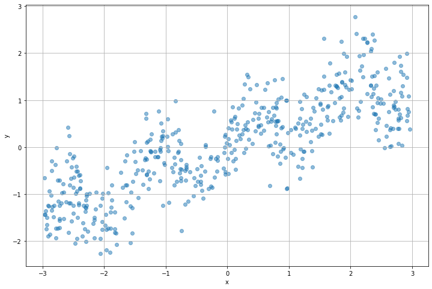

```python
plt.figure(figsize = (12, 8))
plt.scatter(X, y, alpha = 0.5)
plt.xlabel('x')
plt.ylabel('y')
plt.grid()
plt.show()
```

- 위와 같은 데이터 셋을 머신러닝 모델을 이용하여 예측하고자 한다.

```python
X_train, X_test, y_train, y_test = train_test_split(X, y)
```

```python
lr = linear_regressor() # 위에서 만든 지도학습 알고리즘
lr.fit(X_train, y_train) # train data 적합
y_pred_lr = lr.predict(X_test) # 예측 레이블 반환
```

```python
ridge = ridge_regressor() # 위에서 만든 지도학습 알고리즘
ridge.fit(X_train, y_train) # train data 적합
y_pred_ridge = ridge.predict(X_test) # 예측 레이블 반환
```

- 그래프를 통해 확인해보도록 하자

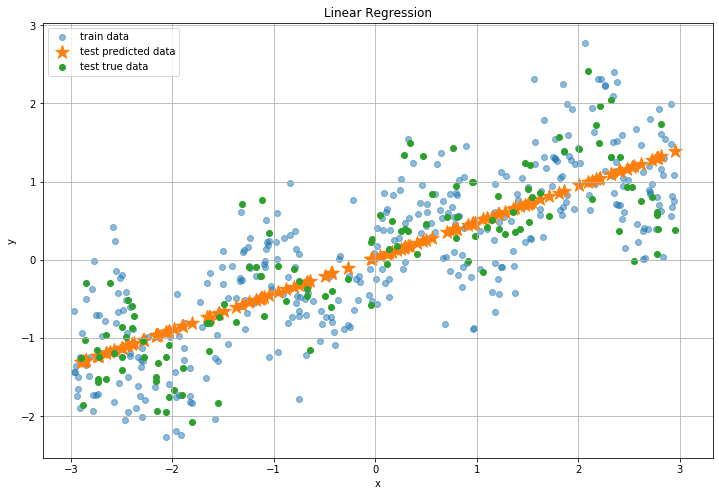

```python
plt.figure(figsize = (12, 8))
plt.scatter(X_train, y_train, alpha = 0.5, label = 'train data')
plt.scatter(X_test, y_pred_lr, marker = '*', s = 200, label = 'test predicted data' )
plt.scatter(X_test, y_test, label = 'test true data')
plt.legend()
plt.title('Linear Regression')
plt.xlabel('x')
plt.ylabel('y')
plt.grid()
plt.show()
```

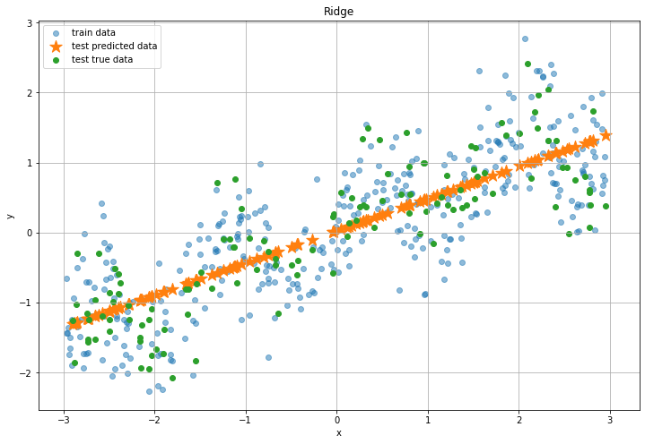

```python
plt.figure(figsize = (12, 8))
plt.scatter(X_train, y_train, alpha = 0.5, label = 'train data')
plt.scatter(X_test, y_pred_ridge, marker = '*', s = 200, label = 'test predicted data' )
plt.scatter(X_test, y_test, label = 'test true data')
plt.legend()
plt.title('Ridge')
plt.xlabel('x')
plt.ylabel('y')
plt.grid()
plt.show()
```

- 예측데이터를 볼 때 선형회귀와 릿지회귀의 큰 차이점은 없어 보인다.
- 선형회귀선과 릿지회귀선을 따로 그어 확인해보자

```python
x = np.arange(-4, 4)
lr_line = lr.weight[1] * x + lr.weight[0]
ridge_line = ridge.weight[1] * x + ridge.weight[0]
```

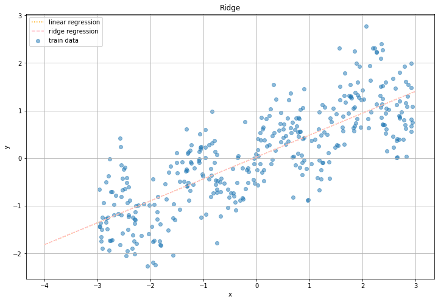

```python
plt.figure(figsize = (12, 8))
plt.scatter(X_train, y_train, alpha = 0.5, label = 'train data')
plt.plot(x, lr_line, c = 'orange', ls = ':', label = 'linear regression')
plt.plot(x, ridge_line, c = 'pink', ls = '--', label = 'ridge regression')
plt.legend()
plt.title('Ridge')
plt.xlabel('x')
plt.ylabel('y')
plt.grid()
plt.show()
```

- 현재 데이터선 주황색 점선인 선형회귀선과 분홍색 점선인 릿지회귀선이 겹치는 것으로 보아 크게 선형회귀 모델과 릿지회귀 모델이 큰 차이를 보이지 않는것으로 보인다.

```python
# linear regression
print('선형회귀계수 :\n', lr.weight)
print()
print('릿지회귀계수 :\n', ridge.weight)
```

```
선형회귀계수 :
 [[0.02661225]
 [0.46004014]]

릿지회귀계수 :
 [[0.02655649]
 [0.45965623]]
```

회귀계수를 확인해보아도 큰 차이는 없어보인다.